# Nba2025

2025-06-26

```r
library(tidyverse)
```

```r
library(ggplot2)
library(dplyr)
```

# Initial Data Import and Manipulation

```r
nba <- read.csv("C:/Users/VanhiChava/Downloads/nba2025.csv")
head(nba)
```

```
##                      NAME TEAM CUR POS  AGE GP  MpG USG.  TO. FTA   FT. X2PA
## 1 Shai Gilgeous-Alexander  Okc Yes   G 26.6 60 34.2 34.5 10.6 537 0.896  941
## 2   Giannis Antetokounmpo  Mil Yes   F 30.2 48 34.1 35.9 14.2 501 0.591  928
## 3            Nikola Jokic  Den Yes   C 30.0 55 36.1 29.2 14.6 331 0.822  805
## 4             Luka Doncic  Dal  No   F 26.0 22 35.7 33.0 13.9 146 0.767  254
## 5         Anthony Edwards  Min Yes   G 23.6 60 36.5 31.7 14.0 373 0.842  630
## 6            Kevin Durant  Pho Yes   F 36.4 49 36.8 28.9 13.8 292 0.825  608
##    X2P. X3PA  X3P.  eFG.   TS.  PpG  RpG  ApG SpG BpG TOpG  P.R  P.A P.R.A   VI
## 1 0.580  342 0.374 0.575 0.644 32.6  5.2  6.2 1.8 1.0  2.5 37.8 38.8  43.9 11.9
## 2 0.623   42 0.190 0.608 0.620 30.8 12.1  6.0 0.8 1.3  3.3 42.8 36.7  48.8 15.3
## 3 0.619  243 0.444 0.630 0.667 28.9 12.7 10.4 1.8 0.7  3.3 41.7 39.4  52.1 17.3
## 4 0.555  212 0.354 0.544 0.584 28.1  8.3  7.8 2.0 0.4  3.4 36.5 36.0  44.3 13.7
## 5 0.471  607 0.405 0.538 0.587 27.4  6.0  4.6 1.2 0.6  3.4 33.4 32.0  38.0 10.0
## 6 0.590  299 0.398 0.593 0.635 26.9  6.0  4.2 0.9 1.3  3.0 32.9 31.1  37.1  9.5
##    ORtg  DRtg
## 1 129.1 105.4
## 2 119.4 104.1
## 3 133.9 107.3
## 4 115.9 106.8
## 5 112.3 109.6
## 6 116.3 116.3
```

# Question Exploration

## What are the top 3 teams that had the highest mean PPG average amongst all untraded players?

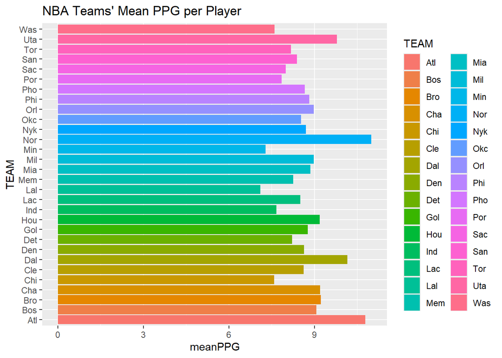

```r
PPG_nba <- nba %>%
  filter(CUR == "Yes") %>%
  group_by(TEAM) %>%
  summarize(sumPPG = sum(PpG),
            total_players = n(),
            meanPPG = sumPPG/total_players)
ggplot(PPG_nba, aes(x = meanPPG, y = TEAM, fill = TEAM)) +
    geom_col() +
    labs(title = "NBA Teams' Mean PPG per Player")
```

```r
PPG_nba %>%
  arrange(meanPPG) %>%
  slice_max(meanPPG, n = 3)
```

```
## # A tibble: 3 × 4
##   TEAM  sumPPG total_players meanPPG
##   <chr>  <dbl>         <int>   <dbl>
## 1 Nor     209             19    11
## 2 Atl     183.            17    10.8
## 3 Dal     203.            20    10.2
```

> The teams with the highest mean PPG among untraded players are: New Orleans Pelicans, Atlanta Hawks, and the Dallas Mavericks.

## What are the top 5 oldest and youngest NBA teams prior to the start of the 2025 NBA season?

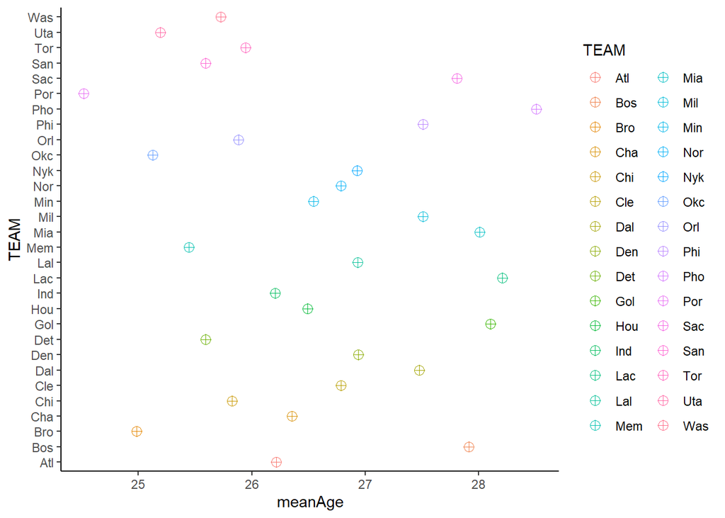

```r
age_nba <- nba %>%
  group_by(TEAM) %>%
  summarize(meanAge = sum(AGE) / n())

ggplot(age_nba, aes(x = meanAge, y = TEAM, color = TEAM)) +
  geom_point(size = 3.0, shape = 10) +
  theme_classic()
```

```r
age_nba %>%
  arrange(meanAge) %>%
  slice_max(meanAge, n = 5)
```

```
## # A tibble: 5 × 2
##   TEAM  meanAge
##   <chr>   <dbl>
## 1 Pho      28.5
## 2 Lac      28.2
## 3 Gol      28.1
## 4 Mia      28.0
## 5 Bos      27.9
```

> The top 5 oldest teams in the NBA are the Phoenix Suns, the Los Angeles Clippers, the Golden State Warriors, the Miami Heat, and the Boston Celtics.

```r
age_nba %>%
  arrange(meanAge) %>%
  slice_min(meanAge, n = 5)
```

```
## # A tibble: 5 × 2
##   TEAM  meanAge
##   <chr>   <dbl>
## 1 Por      24.5
## 2 Bro      25.0
## 3 Okc      25.1
## 4 Uta      25.2
## 5 Mem      25.4
```

> The top 5 youngest teams in the NBA are the Portland Trail Blazers, the Brooklyn Nets, the Oklahoma City Thunder, the Utah Jazz, and the Memphis Grizzlies.

NEXT TIMES: create density plots of ages for the oldest and youngest teams.

## What does the age distribution of players for the NBA teams with the youngest and oldest overall mean age?

Youngest NBA Team:

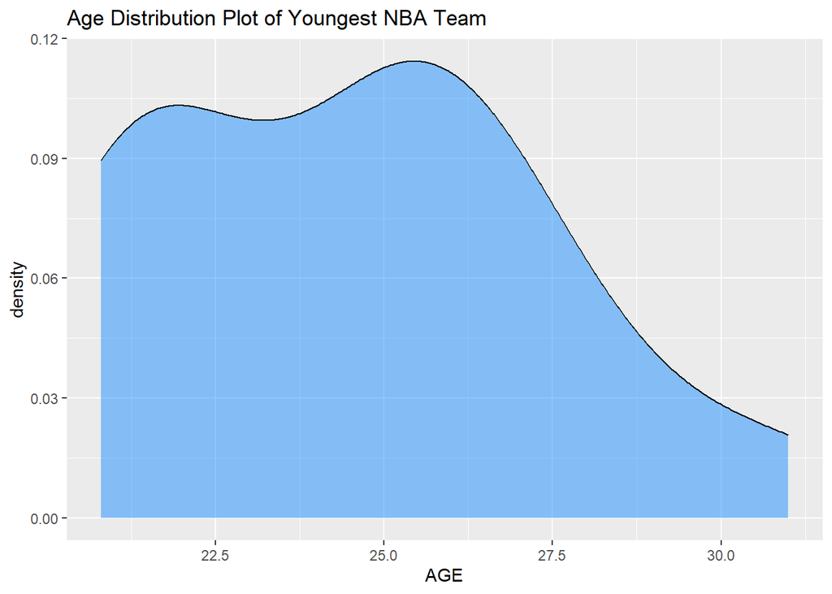

```r
young_nba <- age_nba %>%
  arrange(meanAge) %>%
  slice_min(meanAge, n = 1)
young_team <- young_nba$TEAM[1]

nba %>%
  filter(TEAM == young_team) %>%
  select(NAME, AGE) %>%
  ggplot(aes(x = AGE)) +
    geom_density(fill = "dodgerblue", alpha = 0.5) +
    labs(title = "Age Distribution Plot of Youngest NBA Team")
```

Oldest NBA Team:

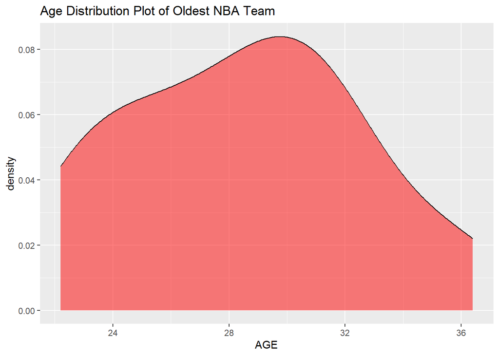

```r
old_nba <- age_nba %>%
  arrange(meanAge) %>%
  slice_max(meanAge, n = 1)
old_team <- old_nba$TEAM[1]

nba %>%
  filter(TEAM == old_team) %>%
  select(NAME, AGE) %>%
  ggplot(aes(x = AGE)) +
    geom_density(fill = "red", alpha = 0.5) +
    labs(title = "Age Distribution Plot of Oldest NBA Team")
```

In order to have a more direct comparison, we will overlap the plots.

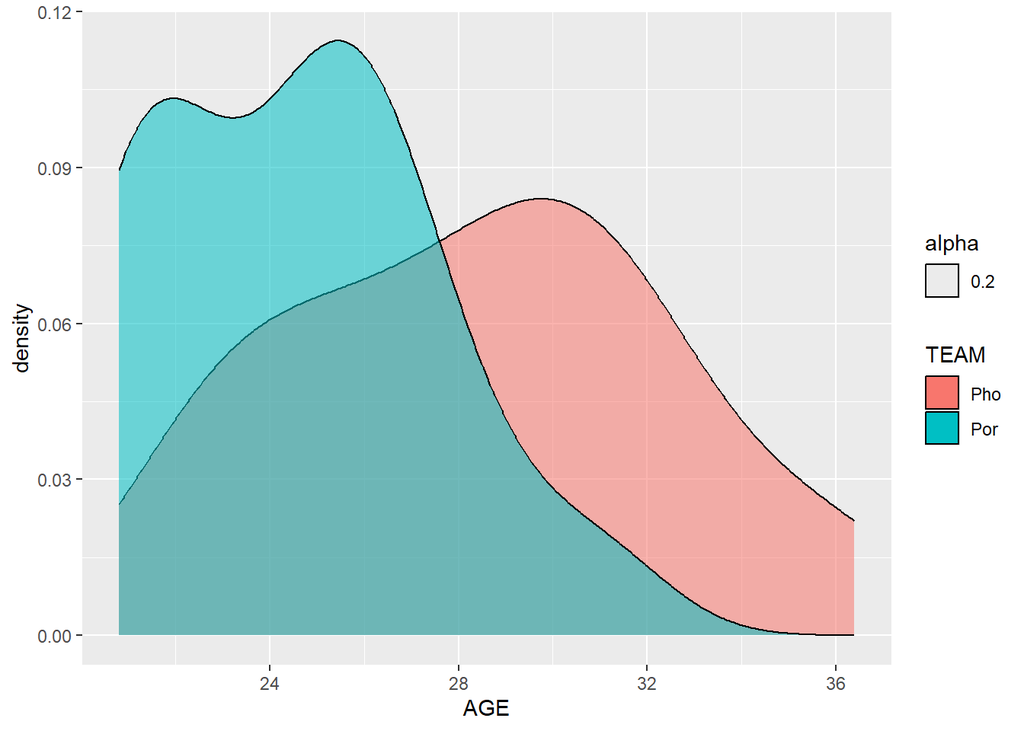

```r
nba %>%
  filter(TEAM == old_team | TEAM == young_team) %>%
  ggplot(aes(x = AGE, fill = TEAM, alpha = 0.2)) +
    geom_density()
```